# BiSSE and HiSSE in R

Dean Adams (dcadams@iastate.edu)

2026-03-04

## Overview

### **Overview**

This tutorial is intended to describe how we investigate whether patterns of species diversification are associated with particular traits. This is examined using state-dependent diversification models, which examine state-dependent speciation and extinction, or $SSE$. These models are used to reflect the belief that rates of species diversification may depend on some trait that is itself changing over time. Here we will be going over how to set up and use BiSSE and HiSSE models in R. **NOTE: much of this tutorial follows the Supplemental tutorial from Chapter 11 in Revell and Harmon (Phylogenetic Comparative Methods in R).**

## Learning Objectives

- Be able to make and fit BiSSE models in R
  - Know how to constrain a BiSSE model
- Evaluate which models are a better fit, either through AIC or Log-likelihoods
- Comprehend the rate matrix of a HiSSE model and be able to make on in R
- Fit a HiSSE model given a phylogeny and data

### Download data files

To run the analyses in this tutorial, we will need several files Chapter 11 of Revell and Harmon, 2022 (Phylogenetic Comparative Methods in R). Please download them from our Git-course repository:

[Grunts Phylogeny](https://github.com/deanadams/MacroevolutionPracticals/blob/main/11-BiSSE_HiSSE/data/grunts.phy)

[Grunts Data](https://github.com/deanadams/MacroevolutionPracticals/blob/main/11-BiSSE_HiSSE/data/grunts.csv)

Additionally, The R-script for running the code found in this tutorial is found here:

[RScript](https://github.com/deanadams/MacroevolutionPracticals/blob/main/11-BiSSE_HiSSE/scripts/HiSSE_BiSSE_tutorial.R)

As before, on your local computer, place them in a folder named ‘TutorialData’, which is found in the same directory as this tutorial.

#### **Conceptual Background**

The Binary State-dependent Speciation and Extinction model is used when we believe that diversification rates depend on some binary character. This model has six parameters, $q_{01}$ and $q_{10}$ which describe the rate at which the binary character transitions from one state to another, and $\lambda_{0}$, $\mu_{0}$, $\lambda_{1}$, and $\mu_{1}$ which describe the diversification dynamics while a lineage is in state $0$ and $1$ respectively. Given a phylogeny and character values, we can estimate these parameters in R to learn about our system of interest.

To conduct the analysis we must bring our data into `R`. We require two packges, `diversitree` and `hisse` to conduct our analyses, so we need to install these first:

```r
install.packages("diversitree")
install.packages("hisse")
```

### **Demonstating the Pattern: Simulation**

First however, let’s demonstrate the types of patterns we wish to examine, by conducting a small simulation. Here we simulate lineage diversification under the BiSSE model, where speciation and extinction depend on a discrete character state. This is accomplished using the 6 parameters above. Then, for comparison we will simulate under a birth-death model, but with no dependency on the discrete character. We will accomplish this using the function `tree.bisse`:

```r
par(mfrow=c(1,2))

pars1 <- setNames(c(0.1, 0.3, 0.01, 0.01, 0.03, 0.03),
          c("lambda0", "lambda1", "mu0", "mu1", "q01", "q10"))
pars1
```

```
## lambda0 lambda1     mu0     mu1     q01     q10
##    0.10    0.30    0.01    0.01    0.03    0.03
```

```r
#simulate BiSSE tree
phy.bisse <- tree.bisse(pars1, max.taxa = 80, x0 = 0)

h <- history.from.sim.discrete(phy.bisse,0:1)
plot(h,phy.bisse,show.tip.label=FALSE,
     cols=c("black","grey"), cex=0.7)
mtext("a")

pars2 <- setNames(c(0.2, 0.2, 0.01, 0.01, 0.03, 0.03),
          c("lambda0", "lambda1", "mu0", "mu1", "q01", "q10"))
pars2
```

```
## lambda0 lambda1     mu0     mu1     q01     q10
##    0.20    0.20    0.01    0.01    0.03    0.03
```

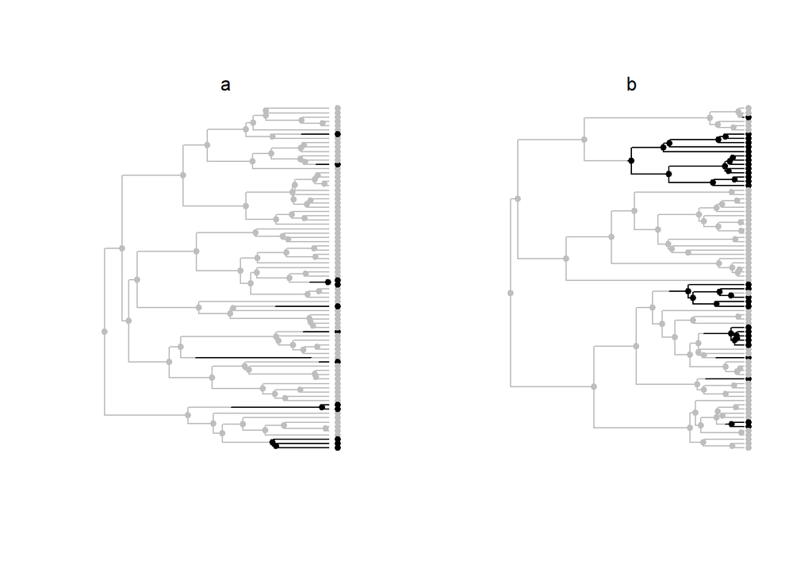

```r
#simulate non-BiSSE tree
phy.nonbisse <- tree.bisse(pars2, max.taxa = 80, x0 = 0)

h2 <- history.from.sim.discrete(phy.nonbisse,0:1)
plot(h2,phy.nonbisse,show.tip.label=FALSE,
     cols=c("black","grey"), cex=0.7)
mtext("b")
```

```r
par(mfrow=c(1,1))
```

Notice how in the BiSSE scenario (a) there is a tendancy of shorter branches between speciation events associated with the grey trait state, implying a higher rate of speciation (as we simulated!).

### **Bringing Data into R**

Now let’s perform this analysis on some data. First we must bring our data into `R`. The data we will use is the example from Chapter 11 of Revell and Harmon (2022). It contains data on reef and non-reef fishes from Price et al. (2013). Since we have already loaded our packages, we’ll simply read the data here:

```r
#Read the grunts data
gt <- read.tree(file = "../data/grunts.phy")
print(gt, printlen = 2)
```

```
##
## Phylogenetic tree with 50 tips and 49 internal nodes.
##
## Tip labels:
##   Haemulon_scudderi, Haemulon_scudderi_N.sp, ...
##
## Rooted; includes branch length(s).
```

```r
gd <- read.csv(file="../data/grunts.csv", row.names = 1,
                          stringsAsFactors = TRUE)
head(gd)
```

```
##                          habitat habitat.names     trait1       trait2
## Pomadasys_panamensis           0      non-reef -0.1097252 -0.221171872
## Pomadasys_macracanthus         0      non-reef  0.1290682 -0.006984002
## Anisotremus_moricandi          1          reef  0.2853245  0.071222353
## Anisotremus_virginicus         1          reef  0.6064791  0.186049096
## Anisotremus_caesius            1          reef  0.4850071  0.076585754
## Anisotremus_surinamensis       1          reef  0.3441719  0.192564145
##                               trait3
## Pomadasys_panamensis      0.04161698
## Pomadasys_macracanthus   -0.04354035
## Anisotremus_moricandi     0.15465876
## Anisotremus_virginicus    0.23311505
## Anisotremus_caesius       0.08355851
## Anisotremus_surinamensis  0.20246620
```

It’s always a good idea to plot our data:

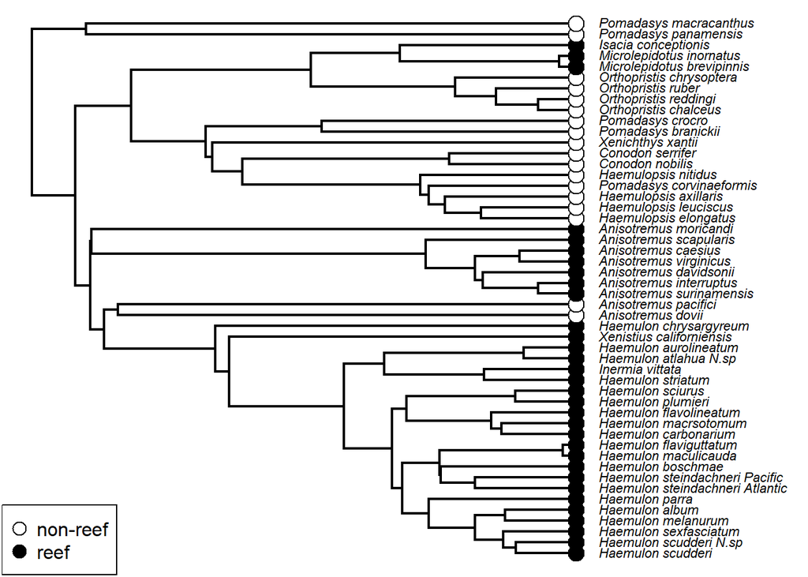

```r
hab <-gd[,1]
names(hab) <- rownames(gd)
plotTree(gt, ftype = "i", fsize = 0.7, offset = 1)
tiplabels(pie=to.matrix(hab,0:1)[gt$tip.label,],
          piecol = c("white", "black"), cex = 0.5)
legend("bottomleft", c("non-reef","reef"),
       pch=21,pt.cex = 1.6, pt.bg = c("white", "black"))
```

### **Running BiSSE**

By visualizing the data we can see the association of the discrete state (reef/non-reef) across the tips of the phylogeny. Now let’s perform a BiSSE analysis on these data to determine whether there is a association. To do so in `diversitree` one must first find some reasonable starting values for the parameters, based no one’s data (which here are found as the MLEs from a model with a sigle mu, lambda, and q:

```r
bisse.model <- make.bisse(gt,hab)
p <- starting.point.bisse(gt)
p
```

```
##   lambda0   lambda1       mu0       mu1       q01       q10
## 48.000124 48.000124  0.000000  0.000000  9.600025  9.600025
```

Now we fit these as starting values for our BiSSE analysis:

```r
bisse.mle <- find.mle(bisse.model, p)
bisse.mle$par
```

```
##      lambda0      lambda1          mu0          mu1          q01          q10
## 3.618175e+01 6.312126e+01 8.394949e-09 2.205760e-06 7.676694e+00 9.638997e-07
```

```r
bisse.mle$lnLik
```

```
## [1] 127.9808
```

Notice now that the parameters are optimized, and differ across states. Next, we need to evaluate this relative to a *constrained* model where the parameters are equal across states:

```r
bisse.null <- constrain(bisse.model, lambda1 ~ lambda0,
                mu1 ~ mu0)
bisse.null.mle <- find.mle(bisse.null, p[c(-2,-4)])
bisse.null.mle$par
```

```
##      lambda0          mu0          q01          q10
## 4.800001e+01 1.773458e-07 7.755575e+00 2.211678e-08
```

```r
bisse.null.mle$lnLik
```

```
## [1] 126.2475
```

Notice with this model that the logL has not changed all that much from the original (perhaps an indication that the more complex model may not be preferred). Let’s test that explicitly:

```r
bisseAnova <- anova(bisse.mle, bisse.null.mle)
bisseAnova
```

```
##         Df  lnLik     AIC  ChiSq Pr(>|Chi|)
## full     6 127.98 -243.96
## model 1  4 126.25 -244.50 3.4666     0.1767
```

```r
aicw(setNames(bisseAnova$AIC, rownames(bisseAnova)))
```

```
##               fit     delta         w
## full    -243.9616 0.5334248 0.4337144
## model 1 -244.4950 0.0000000 0.5662856
```

Notice that the likelihood ratio test is not significant, indicating that the more complex model (BiSSE) does not confer an improvement of fit. Likewise, the AIC comparison reveals that there is no improvement in fit with the more complex model.

### **Running HiSSE**

Now let’s run an $SSE$ model with hidden states, HiSSE. First we set up the hidden states model. Then we run the BiSSE design through the HiSSE analytical machinery.

```r
hd <- data.frame(Genus.species=rownames(gd),
                 x=gd[,"habitat"])
head(hd)
```

```
##              Genus.species x
## 1     Pomadasys_panamensis 0
## 2   Pomadasys_macracanthus 0
## 3    Anisotremus_moricandi 1
## 4   Anisotremus_virginicus 1
## 5      Anisotremus_caesius 1
## 6 Anisotremus_surinamensis 1
```

```r
rates.bisse <- TransMatMakerHiSSE(hidden.traits = 0)
rates.hisse <- TransMatMakerHiSSE(hidden.traits = 1)
rates.bisse
```

```
##     (0) (1)
## (0)  NA   2
## (1)   1  NA
```

```r
rates.hisse
```

```
##      (0A) (1A) (0B) (1B)
## (0A)   NA    2    5   NA
## (1A)    1   NA   NA    5
## (0B)    5   NA   NA    4
## (1B)   NA    5    3   NA
```

Here we set up the various state dependencies (see lecture and relevant literature). What we are doing is preparing to run the HiSSE model with no hidden state (which is equivalent to a BiSSE model), and then with a hidden state. Let’s run those now and compare them (NOTE: this takes a long time to run!):

```r
#NOTE: sann = FALSE and bounded.search = FALSE for tutorial runtime
bisse.hmle <- hisse(gt,hd,turnover = c(1,2),
                eps = c(1,2), hidden.states = FALSE,
                trans.rate = rates.bisse,
                sann = FALSE, bounded.search = FALSE)
```

```
## Initializing...
## Finished. Beginning subplex routine...
## Finished. Summarizing results...
```

```r
#NOTE: sann = FALSE and bounded.search = FALSE for tutorial runtime
hisse.hmle <- hisse(gt,hd,turnover = c(1,1,2,2),
                    eps = c(1,1,2,2), hidden.states = TRUE,
                    trans.rate = rates.hisse,
                    sann = FALSE, bounded.search = FALSE)
```

```
## Initializing...
## Finished. Beginning subplex routine...
## Finished. Summarizing results...
```

```r
bisse.hmle
```

```
##
## Fit
##             lnL             AIC            AICc          n.taxa n.hidden.states
##        127.9808       -243.9616       -242.0081         50.0000          1.0000
##
## Model parameters:
##
##   turnover0A   turnover1A        eps0A        eps1A        q0A1A        q1A0A
## 3.618176e+01 6.312123e+01 2.509354e-18 5.860533e-17 7.676693e+00 1.886955e-14
```

```r
hisse.hmle
```

```
##
## Fit
##             lnL             AIC            AICc          n.taxa n.hidden.states
##        131.4370       -244.8739       -240.3739         50.0000          2.0000
##
## Model parameters:
##
##   turnover0A   turnover1A        eps0A        eps1A        q0A1A        q1A0A
## 6.832736e+01 6.832736e+01 1.177582e-15 1.177582e-15 1.237318e+01 4.717247e-15
##        q0A0B        q1A1B   turnover0B   turnover1B        eps0B        eps1B
## 3.218044e+01 3.218044e+01 0.000000e+00 0.000000e+00 5.906267e+01 5.906267e+01
##        q0B1B        q1B0B        q0B0A        q1B1A
## 2.229066e-13 2.037346e-25 3.218044e+01 3.218044e+01
```

```r
bisse.hmle$AIC
```

```
## [1] -243.9616
```

```r
hisse.hmle$AIC
```

```
## [1] -244.8739
```

For our example, we see that there is not a major improvement of fit (via AIC) when incorporating the hidden state. Thus, the simpler model is preferred.